# DEqMS Package

YAFENG ZHU @ Karolinska Institutet

2018-05-02

## Content

The Vignette is used to guide users to perform differential protein expression analysis:

1. Overview of DEqMS
2. Installation
3. Differential protein expression analysis
   - 3.1 Example Dataset: A431 cells treated with three different miRNA mimics
   - 3.2 Loading the data
   - 3.3 Generate a summary of the data
   - 3.4 Summarization and Normalization
   - 3.5 Ordinary T test
   - 3.6 Anova analysis
   - 3.7 Limma analysis
   - 3.8 Variance dependence on spectra count and non-linear regression
   - 3.9 DEqMS analysis
4. Comparing T test, Anova, Limma and DEqMS
5. Visualization of the results
   - 5.1 PSM/Peptide profile plot
   - 5.2 Volcano plot
   - 5.3 PCA plot
   - 5.4 Sample correlation heatmap

## 1 Overview of DEqMS

`DEqMS` works on top of Limma, a widely-used R package for microarray data analysis (Smyth G. et al 2004), and improve it with mass spectrometry specific data properties, variance dependence on peptide spectra count for statistical testing of differential protein expression.

## 2 Installation

```r
source("../R/DEqMS.R")
library(matrixStats)
library(plyr)
library(limma)
```

## 3 Differential protein expression analysis

### 3.1 Example Dataset: A431 cells treated with three different miRNA mimics

we analyzed a protemoics dataset (TMT10plex labelling) in which A431 cells (human epidermoid carcinoma cell line) were treated with three different miRNA mimics (Yan Z. et al. Oncogene 2016). The raw MS data was searched with MS-GF+ (Kim et al Nat Communications 2016) and post processed with Percolator (K??ll L. et al Nat Method 2007). A tabular text output of PSM intensity table filtered at 1% peptide level FDR is used as input for downstream analysis.

### 3.2 Loading the data and preprocess

Read a tabular input in which PSMs are in rows and samples are in columns. Intenisty values were log transformed since systematic effects and variance components are usually assumed to be additive on log scale (Oberg AL. et al JPR 2008; Hill EG. et al JPR 2008).

```r
dat.psm = readRDS("../data/PXD004163.rds")
colnames(dat.psm)[2] = "gene"
dat.psm = na.omit(dat.psm)

dat.psm.log = dat.psm
dat.psm.log[,3:12] =  log2(dat.psm[,3:12])

head(dat.psm.log)
```

```
##                                           Peptide     gene  ctrl.R1
## 1         +229.163EK+229.163EDDEEEEDEDASGGDQDQEER    RAD21 16.75237
## 2      +229.163LGLGIDEDEVAAEEPNAAVPDEIPPLEGDEDASR HSP90AB1 10.83842
## 3          +229.163TEGDEEAEEEQEENLEASGDYK+229.163    XRCC6 14.50513
## 4       +229.163GDAEK+229.163PEEELEEDDDEELDETLSER   TOMM22 15.03118
## 6       +229.163APLATGEDDDDEVPDLVENFDEASK+229.163     BTF3 12.91401
## 7 +229.163LEEEDEDEEDGESGC+57.021TFLVGLIQK+229.163    CAPN2 14.98558
##   miR191.R1 miR372.R1 miR519.R1  ctrl.R2 miR372.R2 miR519.R2  ctrl.R3
## 1  16.58542  17.26731  16.89528 17.01872  17.57275  17.17815 16.86259
## 2  10.13699  11.11374  11.07481 10.94691  10.79523  11.12735 11.14720
## 3  14.24280  15.23422  14.89865 14.74940  14.97737  15.15129 15.09597
## 4  14.91910  15.41191  15.28128 15.28605  15.41346  15.25669 15.39181
## 6  12.95092  13.00562  13.42180 12.63934  13.62308  13.12880 12.19322
## 7  14.97607  15.30196  15.27979 15.10411  15.31981  15.25233 15.51070
##   miR191.R2 miR372.R3
## 1  17.10233  17.75614
## 2  10.82098  11.21735
## 3  15.01057  15.46617
## 4  15.26239  15.79845
## 6  12.90011  13.52943
## 7  15.72659  16.06221
```

Generate sample annotation table.

```r
cond = c("ctrl","miR191","miR372","miR519","ctrl",
"miR372","miR519","ctrl","miR191","miR372")

sampleTable <- data.frame(
  row.names = colnames(dat.psm)[3:12],
  cond = as.factor(cond)
)
sampleTable
```

```
##             cond
## ctrl.R1     ctrl
## miR191.R1 miR191
## miR372.R1 miR372
## miR519.R1 miR519
## ctrl.R2     ctrl
## miR372.R2 miR372
## miR519.R2 miR519
## ctrl.R3     ctrl
## miR191.R2 miR191
## miR372.R3 miR372
```

### 3.3 Generate a summary of the data

Since each row is one PSM, to count how many PSMs per protein, we simply use function `table` in R to count the number of occurance that each protein ID appears.

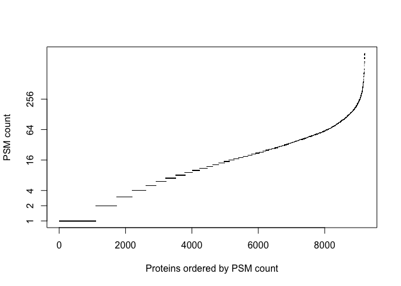

```r
psm.count.table = as.data.frame(table(dat.psm$gene))
rownames(psm.count.table)=psm.count.table$Var1

plot(sort(log2(psm.count.table$Freq)),pch=".",yaxt="n",
     xlab="Proteins ordered by PSM count",ylab="PSM count")
ylab = lab<-c(1,2,4,16,64,256)
axis(2,at=log2(ylab),labels=ylab)
```

### 3.4 Summarization and Normalization

Here, median sweeping is used to summarize PSMs intensities to protein log2 ratios. In this procedure, we substract the spectrum log2 intensity from the median log2 intensities of all samples. The relative abundance estimate for each protein is calculated as the median over all PSMs belonging to this protein. Assume the log2 intensity of PSM `i` in sample `j` is $y_{i,j}$, its relative log2 intensity of PSM `i` in sample `j` is $y'_{i,j}$:
$$y'_{i,j} = y_{i,j} - median_{j'\in ctrl}\ y_{i,j'}$$
Relative abundance of protein `k` in sample `j` $Y_{k,j}$ is calculated as:
$$Y_{k,j} = median_{i\in protein\ k}\ y'_{i,j}$$

Correction for differences in amounts of material loaded in the channels is then done by subtracting the channel median from the relative abundance (log2 ratio), normalizing all channels to have median zero.

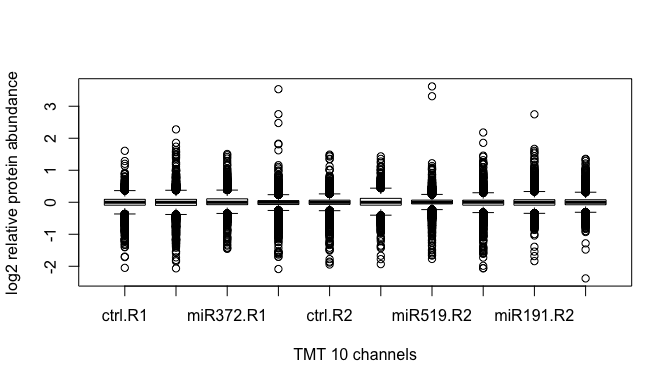

```r
dat.gene.nm = median.sweeping(dat.psm.log,group_col = 2)

boxplot(dat.gene.nm,xlab="TMT 10 channels",ylab="log2 relative protein abundance")
```

### 3.5 Ordinary T test

We first apply t.test to detect significant protein changes between ctrl samples and miR372 treated samples, both have three replicates.

```r
pval.372 = apply(dat.gene.nm, 1, function(x)
  t.test(as.numeric(x[c(1,5,8)]), as.numeric(x[c(3,6,10)]))$p.value)

logFC.372 = rowMeans(dat.gene.nm[,c(3,6,10)]) - rowMeans(dat.gene.nm[,c(1,5,8)])
```

Generate a data.frame of t.test results, add PSM count values and order the table by p-value.

```r
ttest.results = data.frame(gene=rownames(dat.gene.nm),
                           logFC=logFC.372,P.Value = pval.372,
                           adj.pval = p.adjust(pval.372,method = "BH"))

ttest.results$PSMcount = psm.count.table[ttest.results$gene,]$Freq
ttest.results = ttest.results[with(ttest.results, order(P.Value)), ]
head(ttest.results)
```

```
##          gene      logFC      P.Value    adj.pval PSMcount
## CCNE2   CCNE2  0.5380184 5.324681e-07 0.004901901        1
## CPSF2   CPSF2  0.1071365 1.558686e-05 0.065126422       53
## PPOX     PPOX -0.2470977 2.122304e-05 0.065126422        6
## IFIT1   IFIT1  0.6313139 5.095291e-05 0.117268123       34
## TGFBR2 TGFBR2 -1.2413225 9.044387e-05 0.146588290        8
## MAGEA6 MAGEA6  0.4619254 1.050408e-04 0.146588290        6
```

### 3.6 Anova analysis

Anova analysis is equivalent to linear model analysis. The difference to Limma analysis is that estimated variance is not moderated using empirical bayesian approach as it is in Limma. The purpose here is to compare the statistical power to that when Limma is applied. We first make a design matrix and then use `lmFit` function in Limma for linear model analysis. The input for `lmFit` function is a matrix of relative protein abundance (log2 ratios) and a design matrix containing sample annotation. Use `head(fit$coefficients)` to see effect size(fold change) of genes for different conditions.

```r
gene.matrix = as.matrix(dat.gene.nm)
colnames(gene.matrix) = as.character(sampleTable$cond)
design = model.matrix(~cond,sampleTable)

fit1 <- lmFit(gene.matrix,design)

ord.t = fit1$coefficients[, 3]/fit1$sigma/fit1$stdev.unscaled[, 3]
ord.p = 2*pt(-abs(ord.t), fit1$df.residual)
ord.q = p.adjust(ord.p,method = "BH")
anova.results = data.frame(gene=names(fit1$sigma),
                           logFC=fit1$coefficients[,3],
                           t=ord.t,
                           P.Value=ord.p,
                           adj.P.Val = ord.q)

anova.results$PSMcount = psm.count.table[anova.results$gene,]$Freq
anova.results = anova.results[with(anova.results,order(P.Value)),]

head(anova.results)
```

```
##            gene      logFC         t      P.Value   adj.P.Val PSMcount
## ANKRD52 ANKRD52 -1.1924244 -18.65671 1.530399e-06 0.005277799       17
## TGFBR2   TGFBR2 -1.2413225 -18.24613 1.745470e-06 0.005277799        8
## TBC1D2   TBC1D2 -0.5278547 -16.97750 2.670351e-06 0.005277799       26
## PHLPP2   PHLPP2 -0.7976368 -16.49138 3.168669e-06 0.005277799        8
## RELA       RELA -0.5691403 -16.39853 3.275754e-06 0.005277799       32
## CROT       CROT -1.1774687 -16.26291 3.439799e-06 0.005277799       21
```

### 3.7 Limma analysis

Limma is essentially a combination of linear model analysis and empirical bayeisan estimation of variance, the latter is applied to increase the statistical power by borrowing informations across genes to shrink the variance.

```r
fit2 <- eBayes(lmFit(gene.matrix,design))
head(fit2$coefficients)
```

```
##        (Intercept)  condmiR191  condmiR372   condmiR519
## A2M    0.236064231 -0.29781268 -0.51747180 -0.368881337
## A2ML1 -0.150979469  0.29974747  0.10722031  0.372469496
## AAAS   0.083649447 -0.11092503 -0.07317732 -0.157257185
## AACS   0.002446941 -0.06651307 -0.04191091  0.003199874
## AAED1 -0.116809119  0.09168473  0.25332508  0.076127717
## AAGAB -0.022177421  0.18427650  0.11393680  0.001506219
```

Extract limma results using `topTable` function, `coef = 3` allows you to extract the contrast of specific condition (miR372), option `n= Inf` output all rows instead of the top 10. Add PSM count values in the table.

```r
limma.results = topTable(fit2,coef = 3,n= Inf)
limma.results$gene = rownames(limma.results)
limma.results$PSMcount = psm.count.table[limma.results$gene,]$Freq

head(limma.results)
```

```
##              logFC       AveExpr         t      P.Value    adj.P.Val
## ANKRD52 -1.1924244 -0.0934727890 -18.24327 3.334701e-08 0.0001562406
## TGFBR2  -1.2413225  0.0726302421 -18.20504 3.394320e-08 0.0001562406
## CROT    -1.1774687 -0.0519760350 -16.52825 7.663476e-08 0.0002351665
## PHLPP2  -0.7976368 -0.0006579794 -14.41697 2.406114e-07 0.0005537672
## PDCD4   -0.7807229  0.0077638483 -13.13285 5.221109e-07 0.0009613105
## RELA    -0.5691403  0.0009397334 -11.93613 1.146955e-06 0.0013908009
##                B    gene PSMcount
## ANKRD52 8.895452 ANKRD52       17
## TGFBR2  8.882912  TGFBR2        8
## CROT    8.286987    CROT       21
## PHLPP2  7.388343  PHLPP2        8
## PDCD4   6.742717   PDCD4       40
## RELA    6.059352    RELA       32
```

### 3.8 Variance dependence on spectra count

We observed that the variance of gene across samples gradually decreases as the number of spectra count increases.

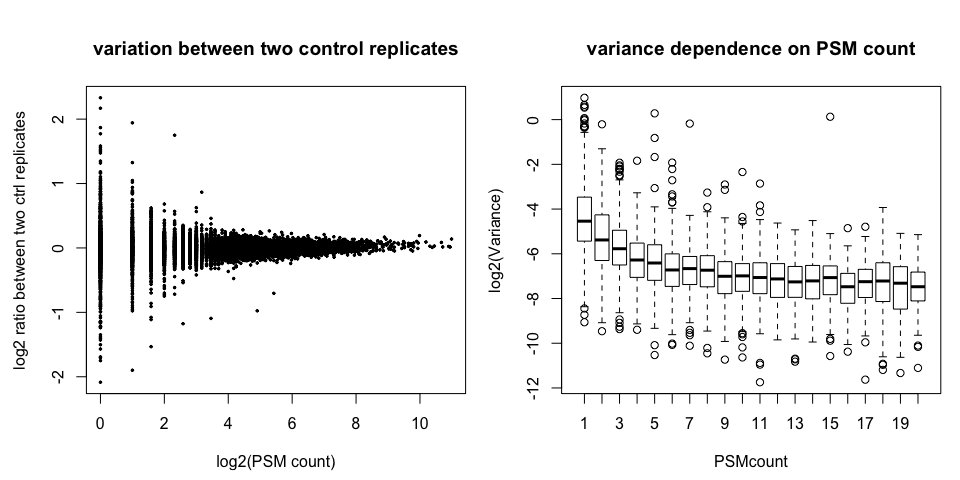

```r
dat.temp = data.frame(var = fit2$sigma^2,PSMcount = psm.count.table[names(fit2$sigma),]$Freq)
dat.temp.filter = dat.temp[dat.temp$PSMcount<21,]

op <- par(mfrow=c(1,2), mar=c(4,4,4,1), oma=c(0.5,0.5,0.5,0))
plot(log2(psm.count.table[rownames(dat.gene.nm),2]),dat.gene.nm[,1]-dat.gene.nm[,5],pch=20,cex=0.5,
     xlab="log2(PSM count)",ylab="log2 ratio between two ctrl replicates",main="variation between two control replicates")

boxplot(log2(var)~PSMcount,dat.temp.filter,xlab="PSMcount",ylab="log2(Variance)",main="variance dependence on PSM count")
```

### 3.9 DEqMS analysis

Limma assumes same prior variance for all genes, the function `spectra.count.eBayes` in DEqMS package is able to correct the biase of prior variance estimate for genes identified with different number of PSMs. It works in a similar way to the intensity-based hierarchical Bayes method (Maureen A. Sartor et al BMC Bioinformatics 2006). Intead of locally weighted regression (Maureen et al 2006) between prior variance and intensity, DEqMS provides two options `loess` or `nls` function to fit prior variance against PSM/peptide count.  
Outputs of `spectra.count.eBayes`:  
object is augmented form of “fit” object from `eBayes` in Limma, with the additions being:  
`sca.t` - Spectra Count Adjusted posterior t-value  
`sca.p` - Spectra Count Adjusted posterior p-value  
`sca.dfprior` - estimated prior degrees of freedom  
`sca.priorvar`- estimated prior variance `sca.postvar` - estimated posterior variance `loess.model` - fitted loess model `nls.model` - fitted non-linear model

```r
fit2$count = psm.count.table[names(fit2$sigma),]$Freq

fit3 = spectra.count.eBayes(fit2,coef_col =1:4, fit.method = "loess")
DEqMS.results = output_result(fit3,coef_col = 3)
head(DEqMS.results)
```

```
##              logFC       AveExpr         t      P.Value    adj.P.Val
## ANKRD52 -1.1924244 -0.0934727890 -18.24327 3.334701e-08 0.0001562406
## CROT    -1.1774687 -0.0519760350 -16.52825 7.663476e-08 0.0002351665
## TGFBR2  -1.2413225  0.0726302421 -18.20504 3.394320e-08 0.0001562406
## PDCD4   -0.7807229  0.0077638483 -13.13285 5.221109e-07 0.0009613105
## PHLPP2  -0.7976368 -0.0006579794 -14.41697 2.406114e-07 0.0005537672
## TRPS1   -0.8132491 -0.0459807080 -11.40704 1.661830e-06 0.0013908009
##                B    gene count     sca.t  sca.P.Value sca.adj.pval
## ANKRD52 8.895452 ANKRD52    17 -19.01032 4.209211e-10 3.423507e-06
## CROT    8.286987    CROT    21 -17.77441 8.962504e-10 3.423507e-06
## TGFBR2  8.882912  TGFBR2     8 -17.43066 1.115633e-09 3.423507e-06
## PDCD4   6.742717   PDCD4    40 -14.34371 9.747874e-09 2.243473e-05
## PHLPP2  7.388343  PHLPP2     8 -12.79279 3.416300e-08 6.075762e-05
## TRPS1   5.728598   TRPS1    31 -12.55093 4.204414e-08 6.075762e-05
```

Check if the fitted variance ~ PMS count model is correct.

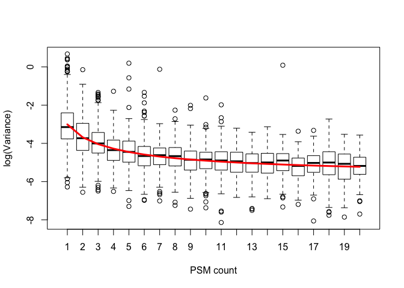

```r
plot.fit.curve(fit3,fit.method = "loess",type = "boxplot",xlab="PSM count")
```

## 4 Comparing T test, Anova, Limma and DEqMS

### 4.1 the effect of spectra.count.eBayes function on prior variance and posterior variance

Visualize the prior variance fitted by Limma and DEqMS

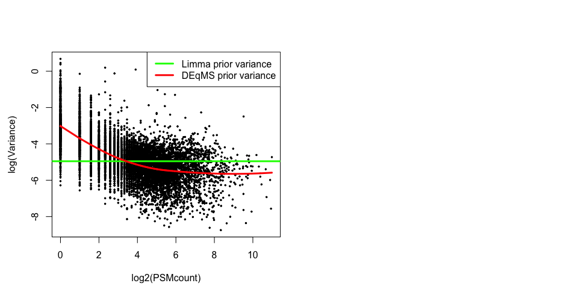

```r
x = fit3$count
y = fit3$sigma^2

limma.prior = fit3$s2.prior
DEqMS.prior = fit3$sca.priorvar
op <- par(mfrow=c(1,2), mar=c(4,4,4,1), oma=c(0.5,0.5,0.5,0))
plot(log2(x),log(y),pch=20, cex=0.5, xlab = "log2(PSMcount)",ylab="log(Variance)")

abline(h = log(limma.prior),col="green",lwd=3 )
k=order(x)
lines(log2(x[k]),log(DEqMS.prior[k]),col="red",lwd=3 )
legend("topright",legend=c("Limma prior variance","DEqMS prior variance"),col=c("green","red"),lwd=3)
```

Visualize the change of posterior variance after PSM count adjustment. The plot here shows posterior variance of proteins “shrink” toward the fitted value to different extent depending on PSM number.

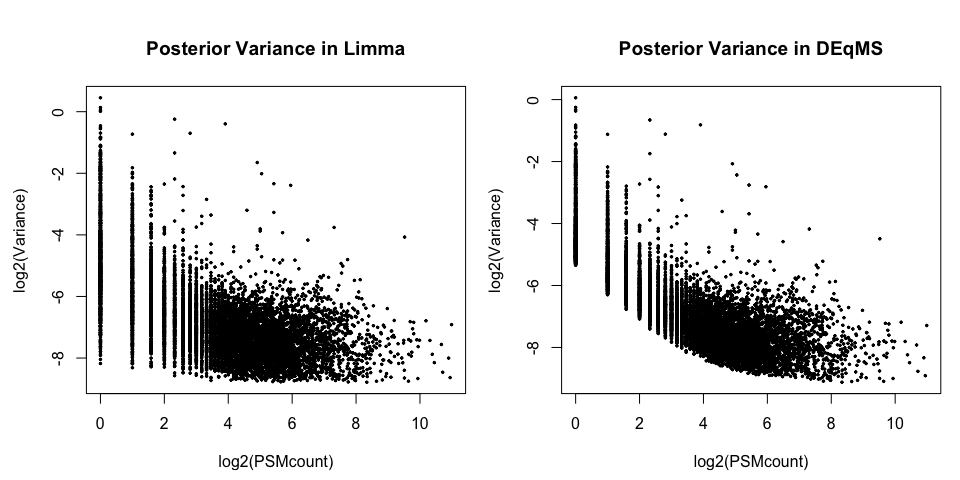

```r
x = fit3$count
y = fit3$s2.post
op <- par(mfrow=c(1,2), mar=c(4,4,4,1), oma=c(0.5,0.5,0.5,0))
plot(log2(x),log2(y),pch=20,cex=0.5 , xlab = "log2(PSMcount)",ylab="log2(Variance)",
     main="Posterior Variance in Limma")

y = fit3$sca.postvar
plot(log2(x),log2(y),pch=20,cex=0.5, xlab = "log2(PSMcount)",ylab="log2(Variance)",
     main="Posterior Variance in DEqMS")
```

### 4.2 Comparing p-values by different analysis.

plotting top 500 genes ranked by p-values.

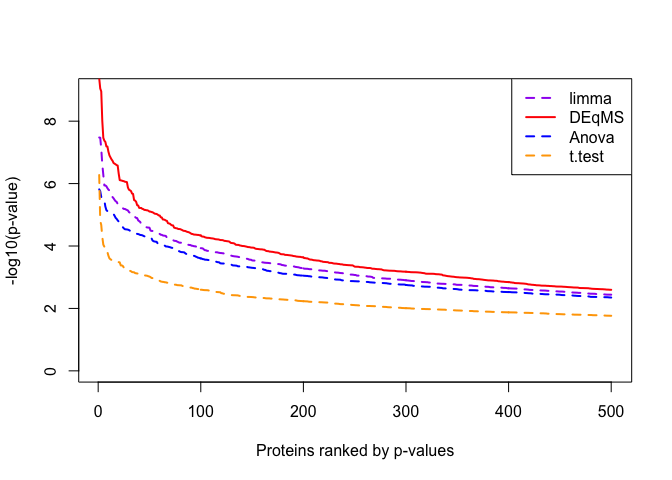

```r
plot(sort(-log10(limma.results$P.Value),decreasing = T)[1:500], type="l",lty=2,lwd=2, ylab="-log10(p-value)",xlab="Proteins ranked by p-values",col="purple",ylim=c(0,9))
lines(sort(-log10(DEqMS.results$sca.P.Value),decreasing = T)[1:500], lty=1,lwd=2,col="red")
lines(sort(-log10(anova.results$P.Value),decreasing = T)[1:500], lty=2,lwd=2,col="blue")
lines(sort(-log10(ttest.results$P.Value),decreasing = T)[1:500], lty=2,lwd=2,col="orange")
legend("topright",legend = c("limma","DEqMS","Anova","t.test"),col = c("purple","red","blue","orange"),lty=c(2,1,2,2),lwd=2)
```

## 5 Visualization of the results

### 5.1 PSM/Peptide profile plot

`make.profile.plot` function will plot log2 intensity of each PSM/peptide of the protein in the input table.

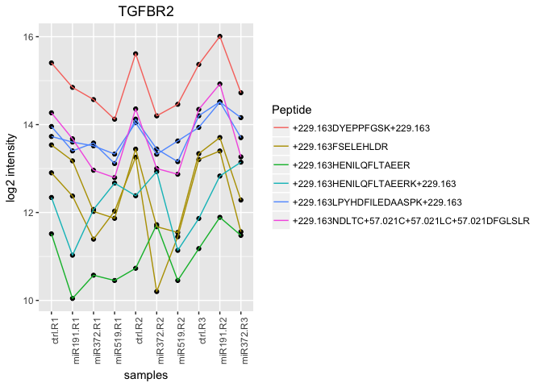

```r
m = dat.psm.log[dat.psm.log$gene=="TGFBR2",]
make.profile.plot(m)
```

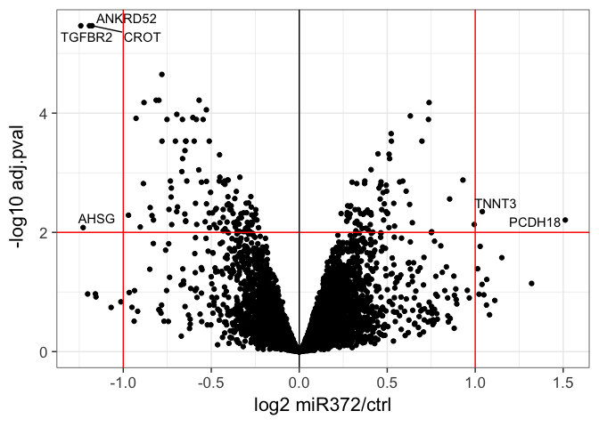

```r
library(ggplot2)
library(ggrepel)

DEqMS.results$log.adj.pval = -log10(DEqMS.results$sca.adj.pval)
ggplot(DEqMS.results, aes(x = logFC, y = log.adj.pval)) +
  geom_point(siz=0.5 )+
  theme_bw(base_size = 16) + # change theme
  xlab(expression("log2 miR372/ctrl")) + # x-axis label
  ylab(expression(" -log10 adj.pval")) + # y-axis label
  geom_vline(xintercept = c(-1,1), colour = "red") + # Add fold change cutoffs
  geom_hline(yintercept = 2, colour = "red") + # Add significance cutoffs
  geom_vline(xintercept = 0, colour = "black") + # Add 0 lines
  scale_colour_gradient(low = "black", high = "black", guide = FALSE)+  # Color black
  geom_text_repel(data=subset(DEqMS.results, abs(logFC) > 1 & log.adj.pval> 2),
                  aes( logFC, log.adj.pval ,label=gene)) # add gene label
```

### 5.3 PCA plot

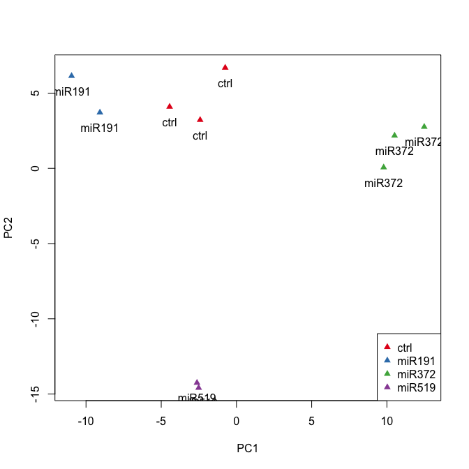

```r
library( RColorBrewer )
pr <- prcomp(t(gene.matrix))
plot( pr$x[,1:2], asp=1, col=brewer.pal(4,"Set1")[sampleTable$cond], pch=17)
text( pr$x[,1], pr$x[,2]-1, label=as.character(sampleTable$cond))
legend( "bottomright", legend = levels( sampleTable$cond ),
   col = brewer.pal(4,"Set1"), pch=17 )
```

### 5.4 Sample correlation heatmaps

plot sample correlation heatmap

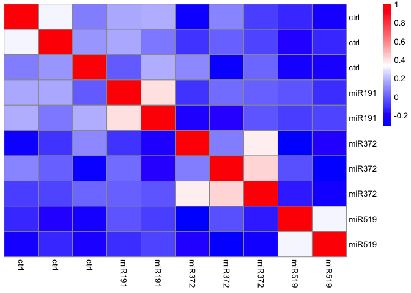

```r
library( pheatmap )
cm <- cor( gene.matrix )
# rearrange columns so that same sample types are together
cm.order = cm[order(colnames(cm)),order(colnames(cm))]

pheatmap( cm.order,
   cluster_rows=FALSE, cluster_cols=FALSE,
   color = colorRampPalette(c("blue", "white", "red"))(100))
```

or plot Eucldiean distance heatmap

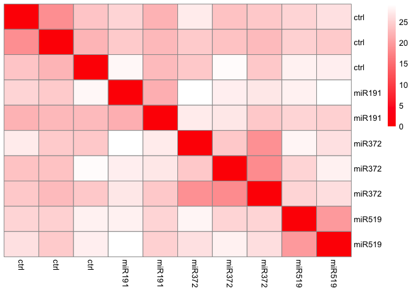

```r
dm <- as.matrix( dist( t( gene.matrix ) ))
dm.order = dm[order(colnames(cm)),order(colnames(cm))]
pheatmap( dm.order,
   cluster_rows=FALSE, cluster_cols=FALSE,
   color = colorRampPalette(c("red", "white"))(100))
```